# 第３回データ分析勉強会

2018年06月06日

## 本日の内容

1. **効率的で綺麗な可視化（午前）**
   - 整然データ（tidy data）と可視化
   - ggplot2とは？
   - ggplot2を使ってみる
   - 復習のためのリソース
2. 効率的で綺麗な可視化（午後）
   - 演習

## 効率的で綺麗な可視化

## 【復習】整然データとは？

- 整然データ（tidy data）とはデータハンドリングを習得する上で知っておくべき概念
  - 一言で表すと「（Coddの）第三正規形」
  - [整然データとは何か (Colorless Green Ideas)](http://id.fnshr.info/2017/01/09/tidy-data-intro/)
  - [整然データってなに？ (Speaker Deck)](https://speakerdeck.com/fnshr/zheng-ran-detatutenani)
- Rで最も使うデータ・フレーム型は整然データにしておくべき
  - 雑然データへの変換は簡単
  - 整然データなら可視化（見える化）も簡単

## ggplot2とは？

- Create Elegant Data Visualisations Using **the Grammar of Graphics**
  - 文字通り統一された文法で様々なグラフを描けるパッケージ
  - tidyverseシリーズなので**整然データ**を前提とした設計
  - といっても現時点ではパイプ演算子（`%>%`）は使えません
- 特徴
  - GIS（地理情報システム）などと同じ[**レイヤー構造**](http://id.fnshr.info/2011/10/22/ggplot2/)
  - **ggplot2::aes**の考え方を覚えるのがひとつのポイント
  - 標準で出来ないないことは**関連パッケージで補える**柔軟性
    - QQプロットはqqplotr, 格子配置はggExtra, etc

## ggplot2を使ってみる

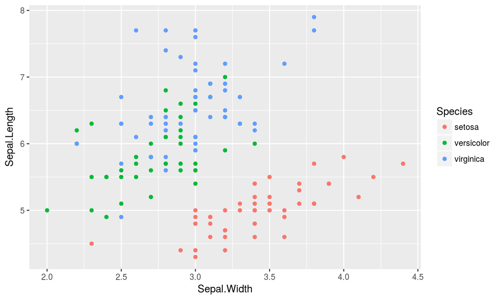

```r
ggplot2::ggplot(data = iris,
                mapping = ggplot2::aes(x = Sepal.Width, y = Sepal.Length,
                                       colour = Species)) +
    ggplot2::geom_point()
```

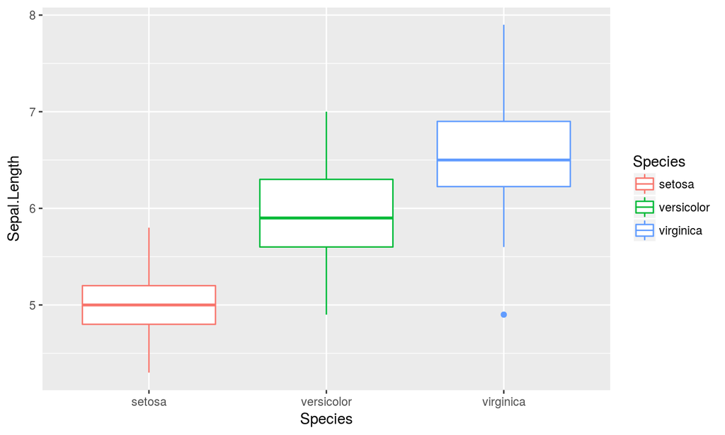

```r
ggplot2::ggplot(data = iris,
                mapping = ggplot2::aes(x = Species, y = Sepal.Length,
                                       colour = Species)) +
    ggplot2::geom_boxplot()
```

## ベースを決める`ggplot2::ggplot`関数

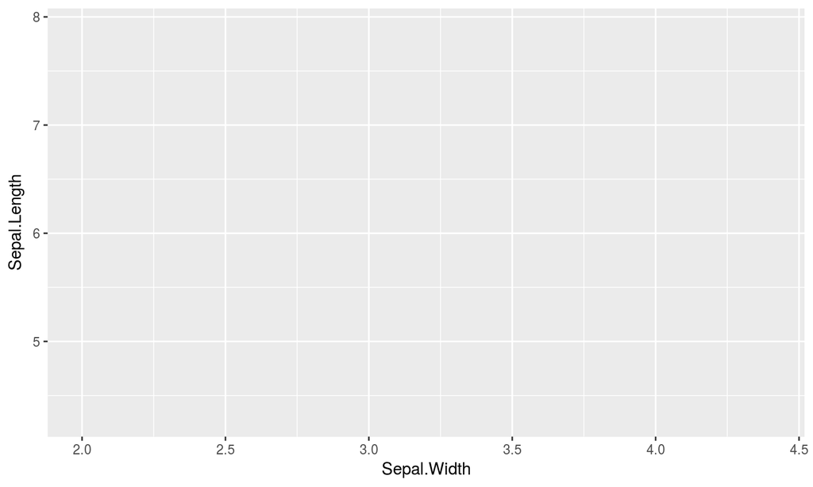

```r
ggplot(iris, aes(x = Sepal.Width, y = Sepal.Length))
```

## ベースに上書きしていくイメージ

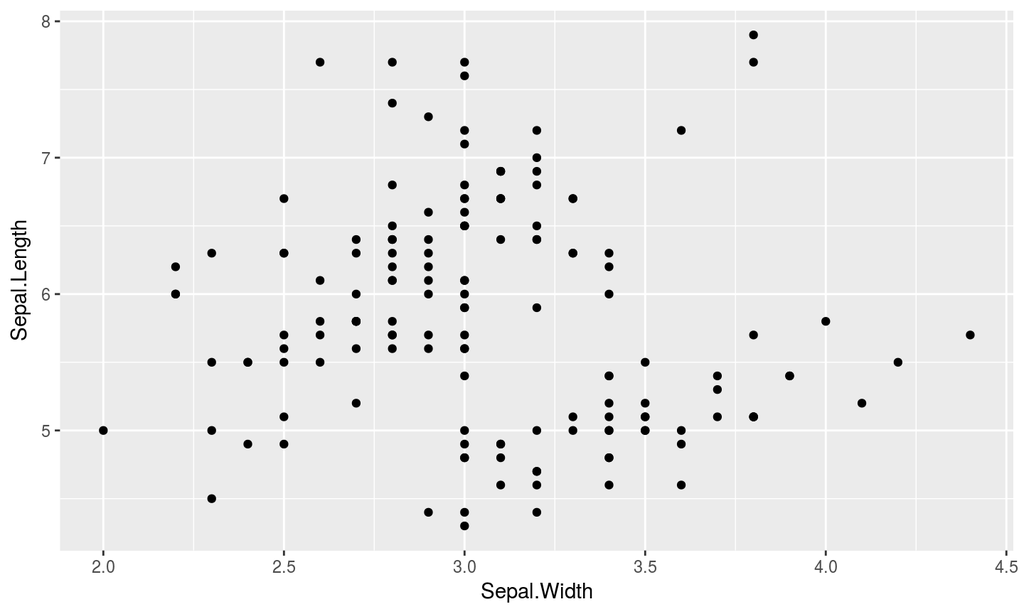

```r
ggplot(iris, aes(x = Sepal.Width, y = Sepal.Length)) +
  ggplot2::geom_point()
```

## `ggplot2::aes`の指定位置がポイント

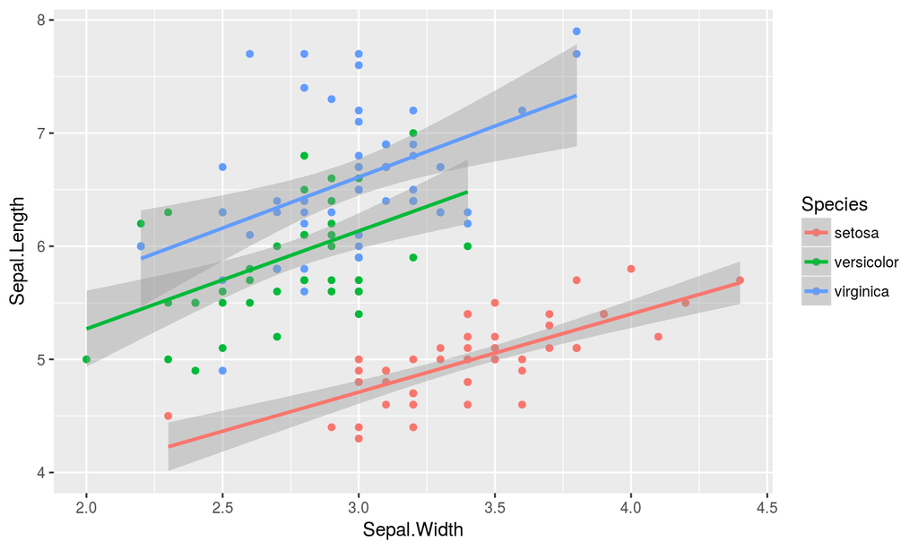

```r
ggplot(iris, aes(x = Sepal.Width, y = Sepal.Length, colour = Species)) +
  geom_point() +
  geom_smooth(method = "lm")
```

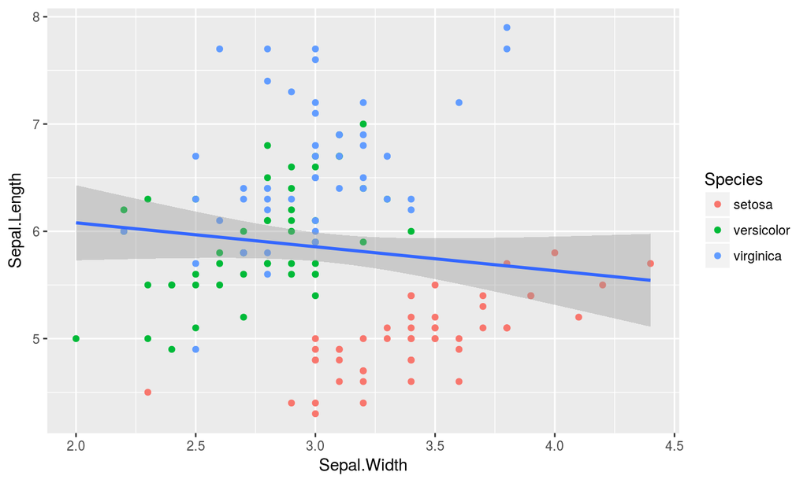

```r
ggplot(iris, aes(x = Sepal.Width, y = Sepal.Length)) +
  geom_point(aes(colour = Species)) +
  geom_smooth(method = "lm")
```

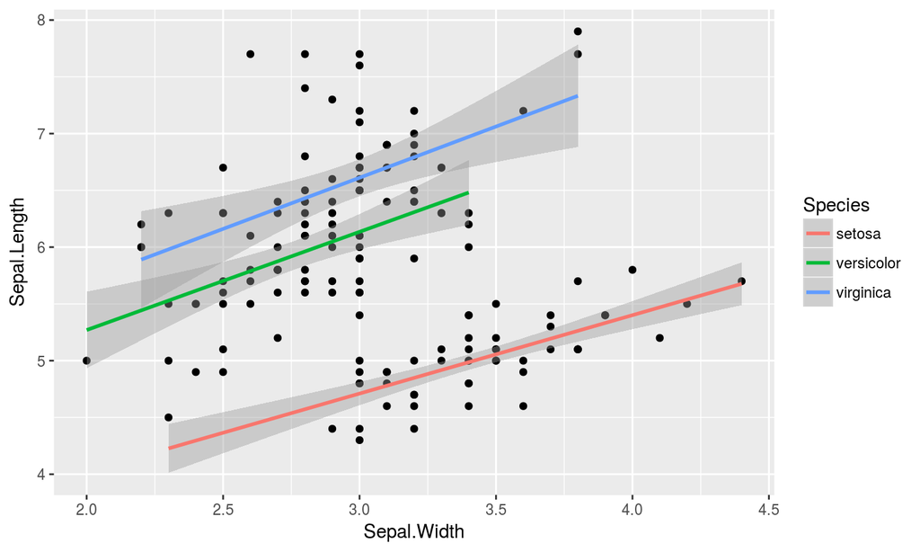

```r
ggplot(iris, aes(x = Sepal.Width, y = Sepal.Length)) +
  geom_point() +
  geom_smooth(aes(colour = Species), method = "lm")
```

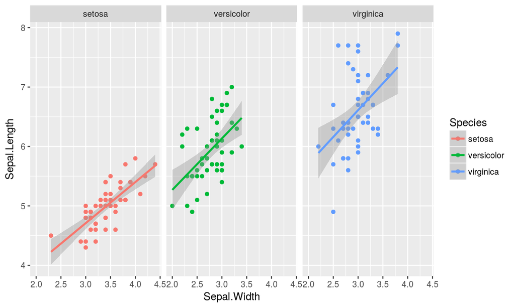

```r
ggplot(iris, aes(x = Sepal.Width, y = Sepal.Length, colour = Species)) +
  geom_point() + geom_smooth(method = "lm") +
  facet_wrap(~ Species)
```

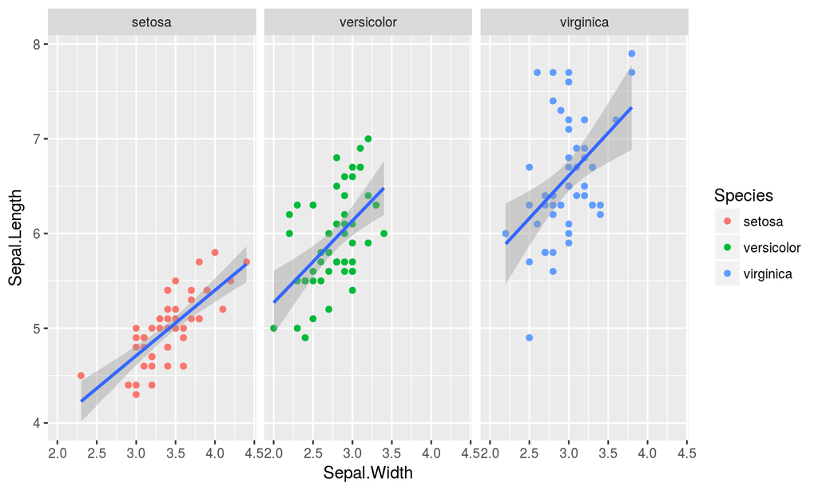

```r
ggplot(iris, aes(x = Sepal.Width, y = Sepal.Length)) +
  geom_point(aes(colour = Species)) + geom_smooth(method = "lm") +
  facet_wrap(~ Species)
```

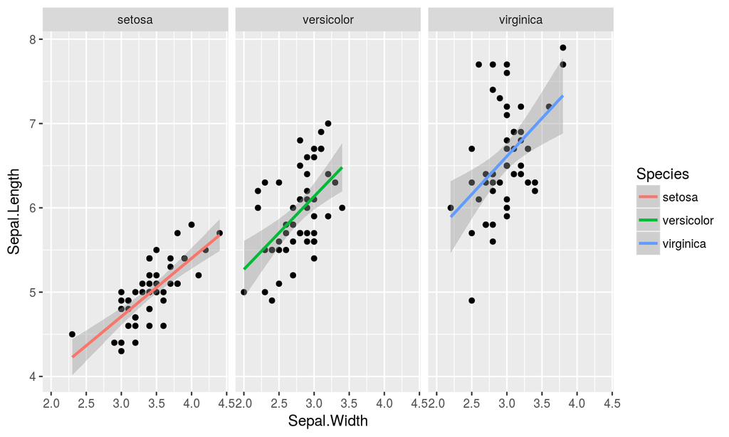

```r
ggplot(iris, aes(x = Sepal.Width, y = Sepal.Length)) +
  geom_point() + geom_smooth(aes(colour = Species), method = "lm") +
  facet_wrap(~ Species)
```

## 主な描画関数

| geom object | 描画内容 | 類似object |
| --- | --- | --- |
| geom_bar | 棒グラフ | geom_col |
| geom_boxplot | 箱ひげ図 | geom_violin |
| geom_dotplot | ドットチャート |  |
| geom_histgram | ヒストグラム | geom_density |
| geom_line | 折れ線グラフ | geom_path |
| geom_smooth | 回帰線 |  |
| geom_text | テキストラベル | geom_label |

## 復習のためのリソース

- [ggplot2のすゝめ](https://k-metrics.github.io/cabinet/program/basics_ggplot2.html)
- [ggplot2あれこれ](https://k-metrics.github.io/cabinet/visualize/index.html)
  - [base/ggplot2]メニュー内に代表的なグラフの描き方を紹介しています
- [ggplot2逆引き](http://yutannihilation.github.io/ggplot2-gyakubiki/)
- [グラフ描画ggplot2の辞書的まとめ20のコード](https://mrunadon.github.io/ggplot2/)
- [ggplot2 — きれいなグラフを簡単に合理的に](https://heavywatal.github.io/rstats/ggplot2.html)
- [Rのグラフィック作成パッケージ“ggplot2”について](http://id.fnshr.info/2011/10/22/ggplot2/)
- [公式Reference（英語）](http://ggplot2.tidyverse.org/reference/index.html)

## License

CC BY-NC-SA 4.0, Sampo Suzuki